# BS_P7-notebook-modèle-AVANCE-lemmatisation

## Sommaire

Ce notebook présente la mise en place du **Modèle sur mesure avancé** (lemmatisation, Word Embeddings Word2Vec & GloVe entraînés avec les modèles de réseaux de neurones profonds).

- Métrique d'évaluation
- Prétraitement
  - Lemmatisation
  - Séparation train/test
- Modèle Keras
  - Vectorisation
  - Sequencing
  - Padding
  - Optimisation d'hyperparamètres
  - Création du modèle
  - Evaluation du modèle
- Word Embeddings
  - Word2Vec
    - W2V Embedding layer
      - Modèle RNN/LSTM
      - Evaluation du modèle
      - Modèle CNN
      - Evaluation du modèle
  - GloVe
    - GloVe Embedding layer
      - Modèle RNN/LSTM
      - Evaluation du modèle
      - Modèle CNN
      - Evaluation du modèle
- BERT
  - Chargement modèle préentraîné
  - Techniques d'attention : identifiants, masques
  - Séparation train/val/mask
  - Création du modèle
  - Evaluation du modèle
- Fichier récapitulatif
- Sources

```python
import pandas as pd
import numpy as np
import random
import os
import re
from collections import Counter
import joblib
import logging
import time
import pickle
import itertools
import urllib.request
from scipy import spatial

import matplotlib.pyplot as plt
%matplotlib inline
import seaborn as sns

# NLP
import nltk
from nltk.corpus import stopwords, wordnet
from nltk.stem import WordNetLemmatizer
from nltk.stem.snowball import SnowballStemmer
import gensim
from gensim.models import Phrases, Word2Vec
from gensim.models.phrases import Phraser
from wordcloud import WordCloud

# Scikit-learn
from sklearn.model_selection import train_test_split
from sklearn.metrics import confusion_matrix, classification_report, roc_curve, auc, precision_score, recall_score, f1_score, accuracy_score
from sklearn.manifold import TSNE

# Keras
import keras
from keras.preprocessing.text import Tokenizer, one_hot
from keras_preprocessing.sequence import pad_sequences
from keras.preprocessing import sequence
from keras.models import Sequential
from keras.layers import Activation, Dense, Dropout, Embedding, Flatten, Conv1D, MaxPooling1D, LSTM, Bidirectional, BatchNormalization
from keras import utils
from keras.callbacks import EarlyStopping, ModelCheckpoint

# TensorFlow
import tensorflow as tf
from tensorflow.keras import layers
```

[output not shown]

```python
# Paramètres en commun
W2V_SIZE = 100
EPOCHS = 30
BATCH_SIZE = 64
CALLBACKS = [
    tf.keras.callbacks.EarlyStopping(
        monitor='val_loss',
        patience=3,  # nb d'epochs
        restore_best_weights=True,
        verbose=1
    )
]
```

```python
def evolution_mesures(model_history):
    pd.DataFrame(model_history.history).plot(figsize=(8, 5))
    plt.grid(True)
    #plt.gca().set_ylim(0,1)
    plt.show()
```

```python
def courbe_roc(model) :
    # Prédiction
    y_pred = model.predict(X_test_vect)

    fpr, tpr, thresholds = roc_curve(y_test, y_pred)
    roc_auc = auc(fpr, tpr)

    plt.figure()
    plt.plot(fpr, tpr, color='red', lw=1, label='ROC curve (area = %0.2f)' % roc_auc)
    plt.xlim([0.0, 1.0])
    plt.ylim([0.0, 1.05])
    plt.xlabel('False Positive Rate')
    plt.ylabel('True Positive Rate')
    plt.title('ROC CURVE')
    plt.legend(loc="lower right")
    plt.show()
```

```python
def overfitting_underfitting(model_history):
    acc = model_history.history['accuracy']
    val_acc = model_history.history['val_accuracy']
    loss = model_history.history['loss']
    val_loss = model_history.history['val_loss']

    epochs = range(len(acc))

    plt.plot(epochs, acc, 'r--', label='Training acc')
    plt.plot(epochs, val_acc, 'g--', label='Validation acc')
    plt.title('Accuracy')
    plt.legend()

    plt.figure()

    plt.plot(epochs, loss, 'r--', label='Training loss')
    plt.plot(epochs, val_loss, 'g--', label='Validation loss')
    plt.title('Loss')
    plt.legend()

    plt.show()
```

```python
def plot_confusion_matrix(cm, classes,
                          title='Confusion matrix',
                          cmap=plt.cm.Greens):
    """
    This function prints and plots the confusion matrix.
    Normalization can be applied by setting `normalize=True`.
    """

    cm = cm.astype('float') / cm.sum(axis=1)[:, np.newaxis]

    plt.imshow(cm, interpolation='nearest', cmap=cmap)
    plt.title(title, fontsize=30)
    plt.colorbar()
    tick_marks = np.arange(len(classes))
    plt.xticks(tick_marks, classes, rotation=90, fontsize=16)
    plt.yticks(tick_marks, classes, fontsize=16)

    fmt = '.2f'
    thresh = cm.max() / 2.
    for i, j in itertools.product(range(cm.shape[0]), range(cm.shape[1])):
        plt.text(j, i, format(cm[i, j], fmt),
                 horizontalalignment="center",
                 color="white" if cm[i, j] > thresh else "black")

    plt.ylabel('True label', fontsize=16)
    plt.xlabel('Predicted label', fontsize=16)
```

```python
def decode_sentiment(score):
    if score < 0.5:
        return 0
    if score > 0.5:
        return 1
```

Commençons par charger le jeu de données contenant l'échantillon de tweets :

```python
# Chargement du jeu de données
sample_df = joblib.load('sample_df')
sample_df.head()
```

|  | Label | Text |
| --- | --- | --- |
| 0 | 0 | fingers still broked yesterday wasn't just a ... |
| 1 | 0 | @shaulala tck ang dayaa!we weren't allowed to ... |
| 2 | 0 | @Zzachary17 awe. I wish I could get on. |
| 3 | 0 | @dream0176 sending hugs your way...sorry to he... |
| 4 | 0 | @peacenlove ok |

```python
sample_df.shape
```

```
(16000, 2)
```

# Métrique d'évaluation

C'est le `score F1` que nous allons utiliser comme métrique d'évaluation. C'est la moyenne pondérée de la précision et du rappel. Ce score prend en compte à la fois les **faux positifs et les faux négatifs**.

- `F1 Score = 2(Recall * Precision) / (Recall + Precision)`
- `Recall = TP/TP+FN`
- `Precision = TP/TP+FP`

En effet, l'idée est de détecter un maximum de tweets négatifs. Tout en sachant que :

- Les vrais négatifs sont labelisés à 0 (TN) => il faut augmenter la Précision
- Les faux positifs sont labelisés à 1 (FN) => il faut également augmenter le Recall afin d'identifier un maximum de vrais positifs.

Nous allons surveiller également l'aire sous la courbe ROC (`AUROC`), le temps écoulé lors de l'entraînement (`Time`) d'un modèle et l'évolution de la perte (`Loss`).

# Preprocessing

Le prétraitement d'un texte nécesite plusieurs étapes :

1. Lemmatisation
2. Split en training & testing set
3. Tokénisation
4. Vectorisation
5. Sequencing

## Lemmatisation

Contrairement au stemming, la lemmatisation est beaucoup plus puissante. Elle va au-delà de la réduction des mots et **applique une analyse morphologique à l'ensemble des mots**. Par conséquent, uniquement les terminaisons flexionnelles sont supprimées.

L'objectif est donc d'obtenir la forme canonique d’un mot, connue sous le nom de **lemme**.

Avant d'appliquer le lemmatiseur, on parcourt les tweets et on ne garde que des tokens contenant plus de 3 éléments.

```python
data = sample_df.copy()
data.Text = sample_df.Text.apply(lambda x: ' '.join([w for w in x.split() if len(w) > 3]))
data.head()
```

|  | Label | Text |
| --- | --- | --- |
| 0 | 0 | fingers still broked yesterday wasn't just dream! |
| 1 | 0 | @shaulala dayaa!we weren't allowed twiter e-class |
| 2 | 0 | @Zzachary17 awe. wish could |
| 3 | 0 | @dream0176 sending hugs your way...sorry hear ... |
| 4 | 0 | @peacenlove |

```python
import nltk
nltk.download('stopwords')
```

```
True
```

```python
stopwords_list = stopwords.words('english')
```

Par la suite, on ôte les caractères spéciaux, la majuscule et les stopwords. Finalement, on effectue une lemmatisation. Pour cela, nous allons utiliser le `WordNetLemmatizer` de NLTK.

#### POS

Afin d'obtenir les formes canoniques, nous allons faire appel aux `pos_tag`, qui permettra de différencier les catégories grammaticales :

```python
# Lemmatize with POS Tag
def get_wordnet_pos(word):
    """Map POS tag to first character lemmatize() accepts"""
    tag = nltk.pos_tag([word])[0][1][0].upper()
    tag_dict = {"J": wordnet.ADJ,
                "N": wordnet.NOUN,
                "V": wordnet.VERB,
                "R": wordnet.ADV}

    return tag_dict.get(tag, wordnet.NOUN)
```

```python
lemmatizer = WordNetLemmatizer()
```

```python
# Test sur une phrase du corpus :
sentence = data.Text[26]
print("Avant : ",sentence)
print("Après : ",[lemmatizer.lemmatize(w, get_wordnet_pos(w)) for w in nltk.word_tokenize(sentence)])
```

```
Avant :  this getting worse, tabs open firefox, since about weeks can't finish reading stuff, lack time killing
Après :  ['this', 'get', 'bad', ',', 'tab', 'open', 'firefox', ',', 'since', 'about', 'week', 'ca', "n't", 'finish', 'reading', 'stuff', ',', 'lack', 'time', 'kill']
```

```python
cleaning_re = "www.[^s]+|@\S+|https?:\S+|http?:\S|[^A-Za-z]+"

def preprocess_lemma(sentence):
    # Remove link,user and special characters + lowercase
    sentence = re.sub(cleaning_re, ' ', str(sentence).lower()).strip()
    sentence = re.sub(r'(.)1+', r'1', sentence) # remove repeating characters

    # Tokénisation
    tokens = []
    for token in sentence.split():
        if token not in stopwords_list:
            tokens.append(lemmatizer.lemmatize(token, get_wordnet_pos(token)))
            #tokens.append(lemmatizer.lemmatize(token))
    return " ".join(tokens)
```

Test de la fonction sur le même tweet du corpus :

```python
print("Avant : ",data.Text[26])
print("Après : ",preprocess_lemma(data.Text[26]))
```

```
Avant :  this getting worse, tabs open firefox, since about weeks can't finish reading stuff, lack time killing
Après :  get bad tab open firefox since week finish reading stuff lack time kill
```

Appliquons la transformation sur l'ensemble du corpus :

```python
data['my_tokens'] = data.Text.apply(lambda x: preprocess_lemma(x))
data.reset_index(drop=True, inplace=True)
data.head()
```

|  | Label | Text | my_tokens |
| --- | --- | --- | --- |
| 0 | 0 | fingers still broked yesterday wasn't just dream! | finger still broked yesterday dream |
| 1 | 0 | @shaulala dayaa!we weren't allowed twiter e-class | dayaa allow twiter e class |
| 2 | 0 | @Zzachary17 awe. wish could | awe wish could |
| 3 | 0 | @dream0176 sending hugs your way...sorry hear ... | send hug way sorry hear |
| 4 | 0 | @peacenlove |  |

```python
data_lemmatized = data.copy()
```

```python
# Sauvegarde du fichier
joblib.dump(data_lemmatized, 'data_lemmatized')
```

```
['data_lemmatized']
```

Les résultat est satisfaisant : la nouvelle variable regroupe les séquences nettoyées et transformées en lemmes.

## Split en test & train set

```python
train, test = train_test_split(data, test_size=0.3, random_state=10)
print("TRAIN size:", len(train))
print("TEST size:", len(test))
```

```
TRAIN size: 11200
TEST size: 4800
```

```python
def preprocess_inputs(df) :
    df = df.copy()

    # Split df into X and y
    y = df['Label'].astype(int)
    X = df['my_tokens']

    # Train-test split
    X_train, X_test, y_train, y_test = train_test_split(X, y, train_size=0.7, shuffle=True, random_state=1)


    return X_train, X_test, y_train, y_test
```

```python
X_train, X_test, y_train, y_test = preprocess_inputs(data)
```

```python
X_train
```

```
2477       boring every go sleep thought freak night guess
2076                               need speed crashe veces
6616                         lesson learn dont home school
10870       hubby hate foot dashboard everytime long drive
11861                       finish watch last vid congrats
                               ...
905                                         go around wish
5192     wasnt home update fone frmo dinner vacation go...
12172    drake drake drake damn crairenae watch shout n...
235                 think come something feel like crapppp
13349                                         morning babe
Name: my_tokens, Length: 11200, dtype: object
```

```python
y_train
```

```
2477     0
2076     0
6616     0
10870    1
11861    1
        ..
905      0
5192     0
12172    1
235      0
13349    1
Name: Label, Length: 11200, dtype: int64
```

# Keras

Dans un premier temps nous allons mettre en place un modèle Keras avec une couche embedding basique. Nous allons optimiser certains de ses hyperparamètres.

Plusieurs étapes avant l'entraînement du modèle :

- vectorisation (indexation)
- sequencing
- padding
- recherche d'hyperparamètres
- création du modèle

### Vectorisation

Nous allons créer une instance de la classe Tokenizer disponible depuis le module `keras.preprocessing.text`. Le tokéniseur parcourra chaque séquence afin de :

- séparer les mots, c'est-à-dire tokéniser
- introduire les minuscules et ôter la ponctuation
- **classer chaque mot en fonction de sa fréquence**
- **attribuer des integers en fonction de la classification de chaque mot**

L'objectif ici est donc **d'attribuer un index à chaque tweet** pour, à la fin, le transformer en une séquence d’entiers.

```python
# Create tokenizer
tokenizer = tf.keras.preprocessing.text.Tokenizer()
```

Ensuite, on fait appel à la méthode `fit_on_texts()`, qui permet de **créer un dictionnaire contenant les entiers étant l’index d’un mot**. Affichons la classification de tous les mots dudit dictionnaire :

```python
# Fit the tokenizer
tokenizer.fit_on_texts(X_train)
```

```python
tokenizer.word_index
```

[output not shown]

[output cut: 946 more lines]

[output not shown]

Les mots le plus souvent mentionnées dans les tweets sont : *good, go, like, work*, les mêmes termes que lors de la stemmatisation. Vérifions combien de mots contient le dictionnaire :

```python
#How many words ?
len(tokenizer.word_index)
```

```
11802
```

### Sequencing

C'est grâce à la méthode `texts_to_sequences()` qu'il est possible de transformer le texte en chiffres. Plus concrètement, elle permet d'effectuer **un mapping d'identifiants numériques représentant l'index de chaque mot dans le dictionnaire.** Ainsi, chaque tweet sera transformé en une array :

```python
# replace the text by its integers
tokenizer.texts_to_sequences(X_train)
```

[output not shown]

[output cut: 1141 more lines]

```python
#np.array(tokenizer.texts_to_sequences(X_train))
```

### Padding

Avant de passer nos séquences transformées au modèle, il faut se pencher sur le problème de leur longueur.

**La longueur de séquences est variable**. Dans l'idéal, il faudrait les "standardiser". Pour cela, il faut identifier la séquence la plus longue et ensuite faire appel au `padding` - c'est-à-dire remplir la liste de zéros.

Attention, les longueurs prédéfinies (`max_seq_length`) doivent être identiques dans le train set et le test set !

```python
# Création de la liste
seq = tokenizer.texts_to_sequences(X_train)
```

```python
# Combien de tweets dedans ?
len(seq)
```

```
11200
```

```python
# Conversion of x into the length of x
# Affichage sous forme de liste
list(map(lambda x: len(x), seq))[:20]
```

```
[8, 4, 5, 7, 5, 12, 4, 12, 1, 8, 11, 12, 5, 4, 5, 2, 11, 4, 7, 6]
```

Identification de la séquence la plus longue :

```python
np.max(list(map(lambda x: len(x), seq)))
```

```
22
```

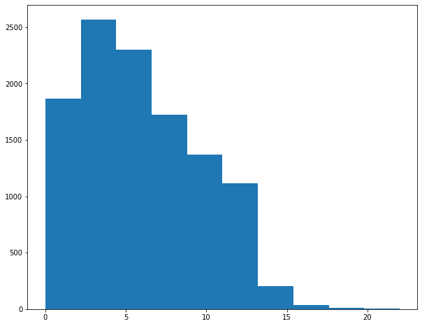

```python
#Visualisation avec histplot :
sequence_lengths = []

for i in range(len(seq)):
    sequence_lengths.append(len(seq[i]))

plt.figure(figsize=(10,8))
plt.hist(sequence_lengths)
plt.show()
```

```python
pd.Series(sequence_lengths).describe()
```

```
count    11200.000000
mean         6.000268
std          3.475104
min          0.000000
25%          3.000000
50%          5.000000
75%          8.000000
max         22.000000
dtype: float64
```

11200 tweets dans notre Train set. Le tweet le plus long contient donc 22 mots.

A présent, mettons en place une fonction permettant de transformer les séquences du train set en integers :

```python
def get_sequences(texts, tokenizer, train=True, max_seq_length=None):
    sequences = tokenizer.texts_to_sequences(texts)

    # Recherche de la séquence la plus longue
    if train == True:
        max_seq_length = np.max(list(map(lambda x: len(x), sequences)))

    # Keras padding function
    sequences = tf.keras.preprocessing.sequence.pad_sequences(sequences, maxlen=max_seq_length, padding='post')

    return sequences
```

```python
get_sequences(X_train, tokenizer, train=True)
```

```
array([[ 412,  324,    2, ...,    0,    0,    0],
       [  19, 1251, 4456, ...,    0,    0,    0],
       [1252,  251,   78, ...,    0,    0,    0],
       ...,
       [2992, 2992, 2992, ...,    0,    0,    0],
       [  16,   23,  108, ...,    0,    0,    0],
       [  36,  863,    0, ...,    0,    0,    0]], dtype=int32)
```

```python
get_sequences(X_train, tokenizer, train=True).shape
```

```
(11200, 22)
```

Nous avons donc 11200 tweets au sein du Train set, chaque tweet a une longueur de 22 integers.

### Prétraitement du corpus

Appliquons à présent toutes les transformations mentionnées sur les jeux de Train et Test à l'aide d'une seule fonction :

```python
SEQUENCE_LENGTH = 22
```

```python
def tokenisation_sequencing(df_train, df_test):
    # Create tokenizer
    tokenizer = tf.keras.preprocessing.text.Tokenizer()

    # Fit the tokenizer
    tokenizer.fit_on_texts(df_train)

    # Convert texts to sequences
    df_train = get_sequences(df_train, tokenizer, train=True)
    df_test = get_sequences(df_test, tokenizer, train=False,
                           max_seq_length=df_train.shape[1])

    return df_train, df_test
```

```python
X_train_vect, X_test_vect = tokenisation_sequencing(X_train, X_test)
```

```python
X_train_vect.shape
```

```
(11200, 22)
```

```python
X_test_vect.shape
```

```
(4800, 22)
```

```python
y_train.value_counts()
```

```
0    5615
1    5585
Name: Label, dtype: int64
```

```python
y_test.value_counts()
```

```
1    2415
0    2385
Name: Label, dtype: int64
```

Remarque : les classes-cibles sont équitablement réparties.

```python
# Fonction permettant d'arrondir le temps d'exécution
def round_elapsed_time(time_model):
    time_sec=round((time_model),2)
    return time_sec
```

```python
X_train_vect.shape
```

```
(11200, 22)
```

### Optimisation d'hyperparamètres

Pour modéliser la relation qui existe entre les variables prédictives `X_train` et la cible `y_train`, nous allons utiliser un modèle de réseau de neurones.

Avant cela, **nous allons rechercher les hyperparamètres les plus adaptés** afin d'obtenir les meilleures performances. Nous allons passer en revue les hyper-paramètres suivants : le nombre de neurones dans la première couche dense, le learning rate et le nombre d'epochs.

#### Architecture du modèle

A présent nous allons créer l'architecture du modèle, tout en définissant l'espace de recherche d'hyperparamètres.

Une fois les hyperparamètres optimisés identifiés, **nous allons créer un hypermodèle, c'est-à-dire le modèle que l'on configure avec l'hyperréglage**.

```python
def model_builder(hp):
    model = keras.Sequential()
    model.add(keras.layers.Input(shape=(22,)))

    # Couche Embedding
    model.add(Embedding(input_dim=len(tokenizer.word_index)+1, output_dim=64))

    # Tune the number of units in the first Dense layer
    hp_units = hp.Int('units', min_value=10, max_value=100, step=32)      # Choose an optimal value between 10 and 100
    model.add(keras.layers.Dense(units=hp_units, activation='relu'))
    model.add(keras.layers.Flatten())
    model.add(keras.layers.Dense(1, activation='sigmoid'))

    # Tune the learning rate for the optimizer
    hp_learning_rate = hp.Choice('learning_rate', values=[1e-2, 1e-3, 1e-4])# Choose an optimal value from 0.01, 0.001, or 0.0001

    # Compilation du modèle
    model.compile(
        optimizer=keras.optimizers.Adam(learning_rate=hp_learning_rate),
        loss='binary_crossentropy',
        metrics=[
            'accuracy',
            tf.keras.metrics.AUC(name='auc')
        ]
    )

    return model
```

#### Instanciation du tuner

`Le Keras Tuner` est une bibliothèque qui permet de choisir l'ensemble optimal d'hyperparamètres pour un algorithme donné. La bibliothèque dispose de quatre tuners :

- RandomSearch
- Hyperband
- BayesianOptimization
- Sklearn

Nous allons instancier **le tuner Hyperband**.

```python
import keras_tuner as kt

tuner = kt.Hyperband(model_builder,
                     objective='val_accuracy',
                     max_epochs=10,
                     factor=3,
                     directory='my_dir',
                     project_name='tuning_lemma_hp')
```

```
INFO:tensorflow:Reloading Oracle from existing project my_dir/tuning_lemma_hp/oracle.json
INFO:tensorflow:Reloading Tuner from my_dir/tuning_lemma_hp/tuner0.json
```

[output not shown]

```python
stop_early = tf.keras.callbacks.EarlyStopping(monitor='val_loss', patience=5)
```

Exécutons la recherche d'hyperparamètres. Le tuner prend en entrée les mêmes arguments que ceux utilisés pour `tf.keras.model.fit` (plus le callback).

```python
tuner.search(X_train_vect, y_train,
             epochs=20,
             validation_split=0.2,
             callbacks=[stop_early])

# Get the optimal hyperparameters
best_hps=tuner.get_best_hyperparameters(num_trials=1)[0]

print(f"""
La recherche des hyper-paramètres est terminée.
La première couche Dense doit contenir {best_hps.get('units')} neurones.
Learning rate optimale est de {best_hps.get('learning_rate')}.
""")
```

```
INFO:tensorflow:Oracle triggered exit

La recherche des hyper-paramètres est terminée.
La première couche Dense doit contenir 74 neurones.
Learning rate optimale est de 0.001.
```

### Création du modèle

Mettons en place le modèle avec les hyperparamètres obtenus :

```python
model_tuner = tuner.hypermodel.build(best_hps)
```

```python
print(model_tuner.summary())
```

```
Model: "sequential_1"
_________________________________________________________________
 Layer (type)                Output Shape              Param #
=================================================================
 embedding_1 (Embedding)     (None, 22, 64)            755392

 dense_2 (Dense)             (None, 22, 74)            4810

 flatten_1 (Flatten)         (None, 1628)              0

 dense_3 (Dense)             (None, 1)                 1629

=================================================================
Total params: 761,831
Trainable params: 761,831
Non-trainable params: 0
_________________________________________________________________
None
```

```python
history_tuner = model_tuner.fit(X_train_vect, y_train,
                                epochs=50,
                                validation_split=0.2)

val_acc_per_epoch = history_tuner.history['val_accuracy']
best_epoch = val_acc_per_epoch.index(max(val_acc_per_epoch)) + 1

print('Best epoch: %d' % (best_epoch,))
```

```
Best epoch: 2
```

#### Création de l'hyper modèle

On instancie le modèle avec, cette fois-ci, le nombre d'epochs optimisé.

```python
hypermodel = tuner.hypermodel.build(best_hps)

# Retrain the model
start_time = time.time()
history_hypermodel = hypermodel.fit(X_train_vect, y_train,
                                    epochs=best_epoch,
                                    validation_split=0.2)
end_time = time.time()
time_hypermodel = end_time - start_time
```

```python
time_hypermodel = round_elapsed_time(time_hypermodel)
print("Temps d'exécution :", time_hypermodel, "secondes.")
```

```
Temps d'exécution : 5.18 secondes.
```

### Evaluation du modèle

#### Accuracy, AUC, Loss

La méthode `evaluate` du modèle est très utile, elle permet d'avoir un premier aperçu des performances du modèle.

```python
results_hypermodel= hypermodel.evaluate(X_test_vect, y_test, verbose=0)

print("    Test Loss: {:.4f}".format(results_hypermodel[0]))
print("Test Accuracy: {:.2f}%".format(results_hypermodel[1] * 100))
print("     Test AUC: {:.4f}".format(results_hypermodel[2]))
```

```
    Test Loss: 0.6045
Test Accuracy: 69.31%
     Test AUC: 0.7562
```

Affichons l'évolution d'autres métriques (au fil des epochs) :

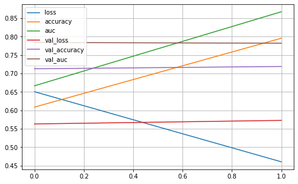

```python
evolution_mesures(history_hypermodel)
```

#### ROC AUC

Affichons le graphique qui illustre la performance du modèle de classification :

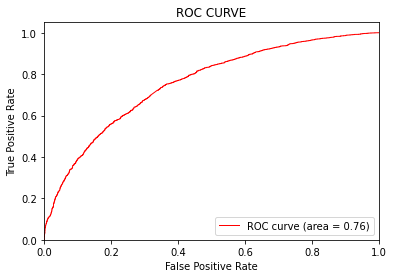

```python
courbe_roc(hypermodel)
```

#### Overfitting / underfitting

Il est intéressant de suivre les changements au niveau de la précision `Accuracy` et perte `Loss` dans les jeux d’entraînement et de validation au fil du processus d’entraînement :

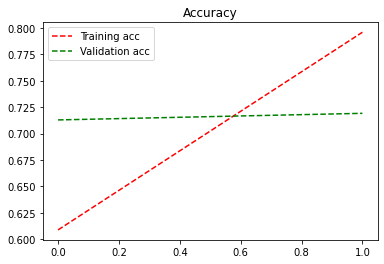

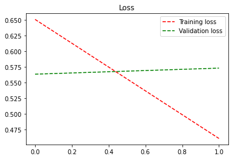

```python
overfitting_underfitting(history_hypermodel)
```

#### Matrice de confusion

```python
y_pred = []
y_test = list(test.Label)
scores = hypermodel.predict(X_test_vect, verbose=0, batch_size=8000)
y_pred = [decode_sentiment(score) for score in scores]
```

```python
print(classification_report(y_test, y_pred))
```

```
              precision    recall  f1-score   support

           0       0.52      0.45      0.48      2452
           1       0.50      0.57      0.53      2348

    accuracy                           0.51      4800
   macro avg       0.51      0.51      0.50      4800
weighted avg       0.51      0.51      0.50      4800
```

```python
# Stock F1
f1_hypermodel=round(f1_score(y_test, y_pred),2)
```

```python
conf_matrix = confusion_matrix(y_test, y_pred)
```

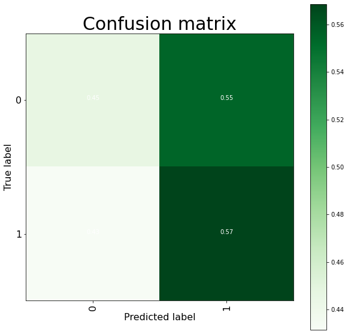

```python
plt.figure(figsize=(10,10))
plot_confusion_matrix(conf_matrix, classes=train.Label.unique(), title="Confusion matrix")
plt.show()
```

### Prédictions pour le modèle simple

```python
print(scores[:5])
```

```
[[0.4534392 ]
 [0.55463386]
 [0.56072396]
 [0.7493996 ]
 [0.21412086]]
```

```python
print(y_pred[:5])
```

```
[0, 1, 1, 1, 0]
```

# Word embeddings

Il s'agit d'une version améliorée de modèles simples de sac de mots (`BOW, TF-IDF, One-Hot Encoder`), qui eux représentent principalement des vecteurs creux. `Word embeddings` sont une meilleure alternative car ils permettent de **capturer le sens, la relation sémantique et le contexte de différents mots** via leur représentation vectorielle (dense).

Nous ferons appel à deux embeddings différents : `Word2Vec` et `Glove`.

## Word2Vec

`Word2Vec` n'est pas un un seul algorithme mais une combinaison de deux techniques - **CBOW (Continuous bag of words) et le modèle Skip-gram.** Il s'agit de réseaux de neurones peu profonds qui mappent le mot à la variable cible qui est également un mot. Ces deux techniques apprennent des poids qui agissent ensuite comme des représentations vectorielles de mots.

- `CBOW` a tendance à prédire la probabilité d'un mot compte tenu du contexte. ** Un contexte peut être un seul mot adjacent ou un groupe de mots environnants.
- Le modèle `Skip-gram` fonctionne de manière inverse - il essaie de prédire le contexte d'un mot donné.

A présent nous entraînerons un modèle Word2Vec sur notre corpus pour obtenir des représentations vectorielles DE tous les mots.

### W2V Embedding layer

Afin de créer une couche d'embedding, il est nécessaire d'entraîner Word2Vec sur le corpus.

Le modèle prend en entrée une liste des phrases propres à partir du train set. Il est nécessaire de spécifier les paramètres suivants :

- la taille de l'espace vectoriel d'intégration (100),
- le nombre de mots voisins à prendre en compte lors de l'apprentissage de l'embedding de chaque mot (5 voisins),
- le nombre de threads à utiliser lors de l'ajustement du modèle (nous en utilisons 8),
- le nombre minimum d'occurrences pour les mots à prendre en compte dans le vocabulaire (1, car nous avons déjà préparé le vocabulaire).

```python
# Split de tweets en arrays
sentences =[_my_tokens.split() for _my_tokens in train.my_tokens]
sentences[:3]
```

```
[['congrats', 'bella', 'miss'],
 ['call', 'lesser', 'evil'],
 ['go',
  'away',
  'still',
  'time',
  'make',
  'library',
  'pick',
  'reading',
  'material',
  'rain',
  'arrives']]
```

```python
# Create embedding
w2v_embedding = Word2Vec(sentences, vector_size=W2V_SIZE, window=5, workers=8, min_count=1)
```

```python
w2v_embedding.build_vocab(sentences)
w2v_embedding.train(sentences, total_examples=len(sentences), epochs=32)
```

```
(1966728, 2144352)
```

```python
#w2v_embedding.wv.key_to_index
```

```python
w2v_embedding.wv.most_similar("work")
```

```
[('mock', 0.8127878308296204),
 ('zzzzzzz', 0.8107113242149353),
 ('quack', 0.8087661266326904),
 ('lisatefft', 0.8047885894775391),
 ('later', 0.8040721416473389),
 ('tgif', 0.7967884540557861),
 ('hiss', 0.7931312322616577),
 ('wnjoying', 0.7887969017028809),
 ('unification', 0.7854381203651428),
 ('break', 0.7853439450263977)]
```

Les mots indiqués par notre modèle word2vec sont donc ceux les plus similaires au mot *work*.

En effet, le modèle a appris des vecteurs **pour chaque mot figurant dans notre corpus**. Par la suite, il utilise la `similarité cosinus` pour retrouver les vecteurs (mots) les plus similaires.

```python
len(w2v_embedding.wv['work']) #The length of the vector is 100
```

```
100
```

#### Vectorisation

Maintenant que nous avons tous les vecteurs en mémoire, nous pouvons les ordonner de manière à ce qu'ils correspondent au codage des integers par `Keras Tokenizer`.

Un integer correspond à **l'index d'un vecteur spécifique dans la couche d'embedding**. Par conséquent, il est important que nous disposions les vecteurs de sorte que les mots encodés correspondent au bon vecteur.

La matrice ci-dessous prend l'embedding `w2v_embedding` et le vocabulaire `tokenizer.word_index` comme arguments et renvoie une matrice avec les vecteurs de mots aux bons emplacements.

```python
# Stockage de la taille totale du vocabulaire à indexer (plus 0 pour les mots inconnus)
vocab_size = len(tokenizer.word_index) + 1
print("Total words", vocab_size)
```

```
Total words 11803
```

Étant donné que nos données contiennent des tweets et pas seulement des mots, nous devrons trouver un moyen d'utiliser les vecteurs de mots du modèle word2vec pour créer une représentation vectorielle pour un tweet entier.

Il existe une solution à ce problème, on peut simplement prendre la moyenne de tous les vecteurs de mots présents dans le tweet. La longueur du vecteur résultant sera la même, c'est-à-dire 100. Nous allons répéter le même processus pour tous les tweets et obtenir leurs vecteurs. Nous aurons obtenu ainsi 100 features word2vec pour nos données.

#### Matrice d'embedding

```python
# Définition de la matrice de taille 100 remplie de 0
matrix_w2v = np.zeros((vocab_size, W2V_SIZE))

# Mapping de tokens indexés avec les vecteurs de l'embedding
for word, i in tokenizer.word_index.items():
    if word in w2v_embedding.wv:
        matrix_w2v[i] = w2v_embedding.wv[word]
print(matrix_w2v.shape)
```

```
(11803, 100)
```

Les vecteurs sont stockés dans `une instance KeyedVectors`, en tant que `model.wv`.

#### Couche d'embedding

Nous pouvons maintenant créer la `couche d'embedding` pour notre modèle deep learning.

```python
embedding_layer_w2v = Embedding(vocab_size, W2V_SIZE,
                                input_length=SEQUENCE_LENGTH,
                                weights=[matrix_w2v],
                                trainable=False)
```

Lorsque nous avons initialisé la couche d'embedding, elle crée en interne une matrice de poids de forme `(vocab_len, embed_len)`. Cette couche prend une liste d'index de tokens en entrée et récupère les mots correspondant à ces index à partir de la matrice de pondération (à l'aide d'une simple indexation d'entiers).

```python
# Trainable = False : to ensure that the network does not try to
# adapt the pre-learned vectors as part of training the network.
```

## Modèle RNN/LSTM

### RNN

Les `Réseaux de Neurones Récurrents` interveinnent lorsque les expériences sont sous la forme de séquences temporelles. Cette structure introduit **un mécanisme de mémoire des entrées précédentes qui persiste dans les états internes du réseau** et peut ainsi impacter toutes ses sorties futures.

Le problème c'est qu'un réseau RNN traditionnel **peut facilement oublier des données** anciennes (ou des mots assez éloignés du mot courant dans un texte) lors de la phase d’apprentissage, car sa mémoire est "courte". C'est grâce au réseau de neurones `Long Short Term Memory` que l'on peut remédier à cela.

### LSTM

Le réseau de neurones `Long Short Term Memory (LSTM)` est utilisé sur des données triées temporellement. L'idée est de savoir quelles décisions ont été prises dans le passé afin de prendre une décision optimale à l’instant t.

Définition de couches `Embedding, Dropout, LSTM, Flatten, Dense` :

```python
# Initalisation du modèle
model_rnn = Sequential([])

# Ajout de couches
model_rnn.add(layers.Input(shape=(22,)))
model_rnn.add(embedding_layer_w2v)

model_rnn.add(Dropout(0.2))
model_rnn.add(layers.LSTM(64, return_sequences=True))
model_rnn.add(layers.Dropout(0.2))
model_rnn.add(layers.LSTM(64, return_sequences=True))
model_rnn.add(layers.Dropout(0.2))
model_rnn.add(layers.LSTM(64, return_sequences=True))
model_rnn.add(layers.Dropout(0.2))
model_rnn.add(layers.LSTM(64, return_sequences=True))
model_rnn.add(layers.Dropout(0.2))

model_rnn.add(layers.Flatten())
model_rnn.add(layers.Dense(1, activation='sigmoid'))
```

```python
print(model_rnn.summary())
```

```
Model: "sequential_3"
_________________________________________________________________
 Layer (type)                Output Shape              Param #
=================================================================
 embedding_3 (Embedding)     (None, 22, 100)           1180300

 dropout (Dropout)           (None, 22, 100)           0

 lstm (LSTM)                 (None, 22, 64)            42240

 dropout_1 (Dropout)         (None, 22, 64)            0

 lstm_1 (LSTM)               (None, 22, 64)            33024

 dropout_2 (Dropout)         (None, 22, 64)            0

 lstm_2 (LSTM)               (None, 22, 64)            33024

 dropout_3 (Dropout)         (None, 22, 64)            0

 lstm_3 (LSTM)               (None, 22, 64)            33024

 dropout_4 (Dropout)         (None, 22, 64)            0

 flatten_3 (Flatten)         (None, 1408)              0

 dense_6 (Dense)             (None, 1)                 1409

=================================================================
Total params: 1,323,021
Trainable params: 142,721
Non-trainable params: 1,180,300
_________________________________________________________________
None
```

```python
# Compilation du modèle
model_rnn.compile(
    optimizer='adam', # L'algorithme d'optimisation pour trouver les poids
    loss='binary_crossentropy', # car classification binaire
    metrics=[
        'accuracy',
        tf.keras.metrics.AUC(name='auc')
    ]
)
```

```python
X_train_vect.shape
```

```
(11200, 22)
```

```python
start_time = time.time()

history_rnn_w2v = model_rnn.fit(X_train_vect, y_train,
                                batch_size=BATCH_SIZE,  # size of subset of data used on each step, default = 32
                                epochs=EPOCHS,  # how many weight updates will be done on the model
                                validation_split=0.2,
                                callbacks=CALLBACKS
                               )
end_time = time.time()
time_rnn_w2v = end_time - start_time
```

```
Epoch 7: early stopping
```

```python
time_rnn_w2v = round_elapsed_time(time_rnn_w2v)
print("Temps d'exécution :", time_rnn_w2v, "secondes.")
```

```
Temps d'exécution : 49.0 secondes.
```

### Evaluation du modèle

#### Accuracy, AUC, Loss

```python
results_rnn_w2v = model_rnn.evaluate(np.array(X_test_vect), np.array(y_test), verbose=0)

print("    Test Loss: {:.4f}".format(results_rnn_w2v[0]))
print("Test Accuracy: {:.2f}%".format(results_rnn_w2v[1] * 100))
print("     Test AUC: {:.4f}".format(results_rnn_w2v[2]))
```

```
    Test Loss: 0.8137
Test Accuracy: 50.67%
     Test AUC: 0.5077
```

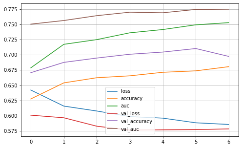

```python
evolution_mesures(history_rnn_w2v)
```

#### ROC AUC

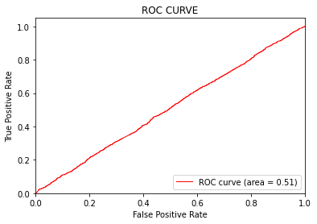

```python
courbe_roc(model_rnn)
```

#### Overfitting / underfitting

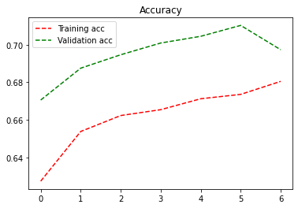

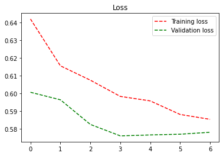

```python
overfitting_underfitting(history_rnn_w2v)
```

#### Matrice de confusion

```python
y_pred = []
y_test = list(test.Label)
scores = model_rnn.predict(X_test_vect, verbose=0, batch_size=8000)
y_pred = [decode_sentiment(score) for score in scores]
```

```python
print(classification_report(y_test, y_pred))
```

```
              precision    recall  f1-score   support

           0       0.52      0.48      0.50      2452
           1       0.50      0.53      0.51      2348

    accuracy                           0.51      4800
   macro avg       0.51      0.51      0.51      4800
weighted avg       0.51      0.51      0.51      4800
```

```python
# Stock F1
f1_rnn_w2v=round(f1_score(y_test, y_pred),2)
```

```python
conf_matrix = confusion_matrix(y_test, y_pred)
```

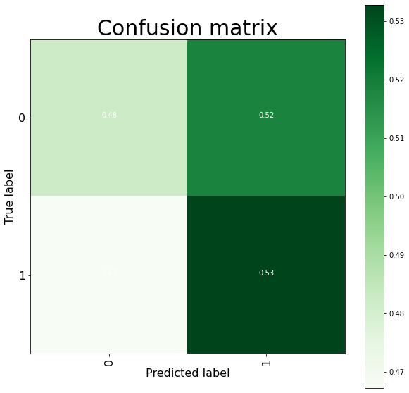

```python
plt.figure(figsize=(10,10))
plot_confusion_matrix(conf_matrix, classes=train.Label.unique(), title="Confusion matrix")
plt.show()
```

### Prédiction avec le modèle RNN

```python
def decode_sentiment_str(score):
    if score < 0.5:
        return 'NEGATIVE'
    if score > 0.5:
        return 'POSITIVE'
```

```python
def predict(text, model):
    start_at = time.time()
    # Tokenize text
    X_test_vect = pad_sequences(tokenizer.texts_to_sequences([text]), maxlen=SEQUENCE_LENGTH)
    # Predict
    score = model.predict([X_test_vect])[0]
    # Decode sentiment
    label = decode_sentiment_str(score)

    return ("Label: ", label,
            "Score: {:.2f}".format(float(score)),
            "Elapsed_time: {:.2f}".format(time.time()-start_at))
```

```python
predict ("I don't like cats", model_rnn)
```

```
('Label: ', 'POSITIVE', 'Score: 0.60', 'Elapsed_time: 1.46')
```

```python
predict ("I love cats", model_rnn)
```

```
('Label: ', 'POSITIVE', 'Score: 0.60', 'Elapsed_time: 0.06')
```

## Modèle CNN

Les réseaux de neurones convolutifs (CNN ou ConvNets) appliquent **une opération de convolution sur les données d'entrée** pour détecter des patterns. CNN se composent d'une ou plusieurs **couches de convolution, chacune contenant des noyaux internes.**

Les CNN sont très couramment utilisés pour des tâches de vision par ordinateur telles que la détection d'objets, la segmentation d'images, la classification d'images, etc. (généralement CNN avec `des couches de convolution 2D`). Cependant, `les CNN avec convolution 1d` peut être utilisé pour des tâches NLP telles que la classification de texte, la génération de texte, etc., car **les données textuelles sont considérées comme des données séquentielles (un signal).**

Le réseau comporte 3 couches, à savoir la couche d'Embedding, la couche de Convolution et la couche Dense. La couche d'Embedding **mappe l'index de tokens sur les embeddings** qui sont transmis à Conv1D pour effectuer une opération de convolution. La sortie de la couche de convolution est transmise à la couche Dense pour **générer des probabilités pour les classes cibles.**

Nous avons déjà notre couche `Embedding`. Il ne reste plus qu'à créer les couches restantes :

- `Conv1D` - chaque filtre dans une convolution extrait une caractéristique (kernel_size = n-grams, nombre de tokens qu'une convolution examine à chaque étape)
- `MaxPooling1D` - couche de Pooling censée compresser les données de la couche précédente de moitié
- `Flatten` - sortie du modèle réduite à un long vecteur 2D pour représenter les « features » extraites par le CNN.
- `Dense` - la couche de sortie qui utilise une `fonction d'activation sigmoïde` pour générer une valeur comprise entre 0 et 1 pour le sentiment négatif et positif dans le tweet.

```python
# define model
model_cnn = Sequential([])
model_cnn.add(embedding_layer_w2v)

model_cnn.add(Conv1D(filters=64, kernel_size=5, activation='relu'))
model_cnn.add(Conv1D(filters=64, kernel_size=5, activation='relu'))
model_cnn.add(BatchNormalization())
model_cnn.add(MaxPooling1D(pool_size=2))
model_cnn.add(Dropout(0.25))

model_cnn.add(Conv1D(filters=64, kernel_size=3, activation='relu'))
model_cnn.add(Conv1D(filters=64, kernel_size=3, activation='relu'))
model_cnn.add(BatchNormalization())
model_cnn.add(MaxPooling1D(pool_size=2))
model_cnn.add(Dropout(0.25))

model_cnn.add(Flatten())
model_cnn.add(Dense(1, activation='sigmoid'))
```

```python
print(model_cnn.summary())
```

```
Model: "sequential_4"
_________________________________________________________________
 Layer (type)                Output Shape              Param #
=================================================================
 embedding_3 (Embedding)     (None, 22, 100)           1180300

 conv1d (Conv1D)             (None, 18, 64)            32064

 conv1d_1 (Conv1D)           (None, 14, 64)            20544

 batch_normalization (BatchN  (None, 14, 64)           256
 ormalization)

 max_pooling1d (MaxPooling1D  (None, 7, 64)            0
 )

 dropout_5 (Dropout)         (None, 7, 64)             0

 conv1d_2 (Conv1D)           (None, 5, 64)             12352

 conv1d_3 (Conv1D)           (None, 3, 64)             12352

 batch_normalization_1 (Batc  (None, 3, 64)            256
 hNormalization)

 max_pooling1d_1 (MaxPooling  (None, 1, 64)            0
 1D)

 dropout_6 (Dropout)         (None, 1, 64)             0

 flatten_4 (Flatten)         (None, 64)                0

 dense_7 (Dense)             (None, 1)                 65

=================================================================
Total params: 1,258,189
Trainable params: 77,633
Non-trainable params: 1,180,556
_________________________________________________________________
None
```

```python
# Compilation du modèle
model_cnn.compile(
    optimizer='adam', # L'algorithme d'optimisation pour trouver les poids
    loss='binary_crossentropy', # car classification binaire
    metrics=[
        'accuracy',
        tf.keras.metrics.AUC(name='auc')
    ]
)
```

```python
X_train_vect.shape
```

```
(11200, 22)
```

```python
X_test_vect.shape
```

```
(4800, 22)
```

Exécutons le modèle sur le train set :

```python
start_time = time.time()

history_cnn_w2v = model_cnn.fit(X_train_vect, y_train,
                                batch_size=BATCH_SIZE,  # size of subset of data used on each step, default = 32
                                epochs=EPOCHS,    # how many weight updates will be done on the model
                                validation_split=0.2,
                                callbacks=CALLBACKS
                               )
end_time = time.time()
time_cnn_w2v = end_time - start_time
```

```
Epoch 8: early stopping
```

```python
## 11.4s
time_cnn_w2v = round_elapsed_time(time_cnn_w2v)
print("Temps d'exécution :", time_cnn_w2v, "secondes.")
```

```
Temps d'exécution : 11.88 secondes.
```

### Evaluation du modèle

#### Accuracy, AUC, Loss

```python
results_cnn_w2v = model_cnn.evaluate(np.array(X_test_vect), np.array(y_test), verbose=0)

print("    Test Loss: {:.4f}".format(results_cnn_w2v[0]))
print("Test Accuracy: {:.2f}%".format(results_cnn_w2v[1] * 100))
print("     Test AUC: {:.4f}".format(results_cnn_w2v[2]))
```

```
    Test Loss: 0.8125
Test Accuracy: 49.73%
     Test AUC: 0.5032
```

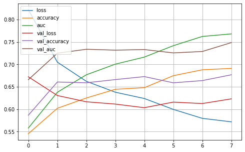

```python
evolution_mesures(history_cnn_w2v)
```

#### ROC AUC

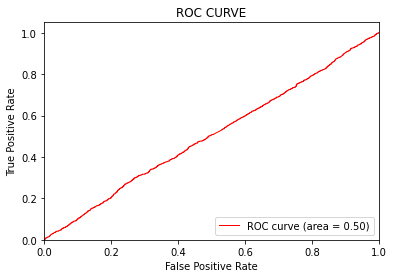

```python
courbe_roc(model_cnn)
```

#### Overfitting / underfitting

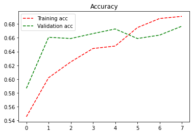

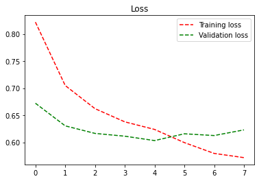

```python
overfitting_underfitting(history_cnn_w2v)
```

#### Matrice de confusion

```python
y_pred = []
y_test = list(test.Label)
scores = model_cnn.predict(X_test_vect, verbose=0, batch_size=8000)
y_pred = [decode_sentiment(score) for score in scores]
```

```python
print(classification_report(y_test, y_pred))
```

```
              precision    recall  f1-score   support

           0       0.51      0.41      0.45      2452
           1       0.49      0.59      0.54      2348

    accuracy                           0.50      4800
   macro avg       0.50      0.50      0.49      4800
weighted avg       0.50      0.50      0.49      4800
```

```python
# Stock F1
f1_cnn_w2v=round(f1_score(y_test, y_pred),2)
```

```python
conf_matrix = confusion_matrix(y_test, y_pred)
```

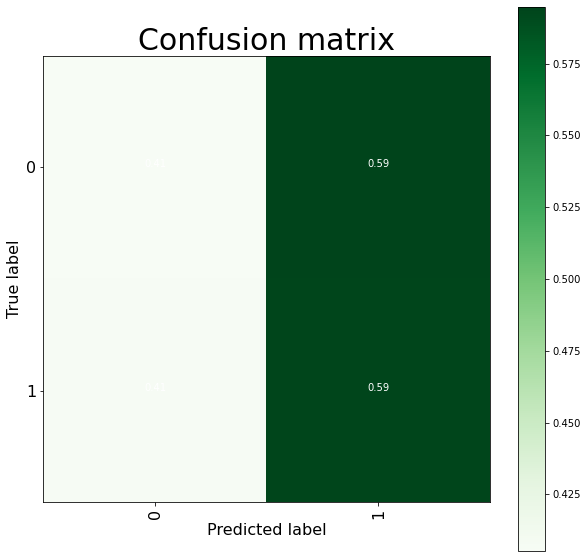

```python
plt.figure(figsize=(10,10))
plot_confusion_matrix(conf_matrix, classes=train.Label.unique(), title="Confusion matrix")
plt.show()
```

#### Prédiction avec le modèle CNN

```python
predict("I hate dogs", model_cnn)
```

```
('Label: ', 'POSITIVE', 'Score: 0.54', 'Elapsed_time: 0.17')
```

```python
predict("I love dogs", model_cnn)
```

```
('Label: ', 'POSITIVE', 'Score: 0.54', 'Elapsed_time: 0.05')
```

# GloVe

`GloVe` signifie `Global Vectors` pour la représentation des mots. Il s'agit d'un algorithme d'apprentissage non supervisé développé par des chercheurs de l'Université de Stanford visant à générer des plongements de mots en agrégeant des matrices globales de cooccurrence de mots à partir d'un corpus donné.

Pour commencer, il faut d'abord télécharger le modèle pré-entraîné hébergé sur https://nlp.stanford.edu/data/glove/. Nous pouvons accéder aux fichiers directement à partir de l'URL avec `urllib` :

```python
#urllib.request.urlretrieve('https://nlp.stanford.edu/data/glove.6B.zip','glove.6B.zip')
```

### Glove Embedding layer

Comme pour Word2Vec, il faut d'abord créer un dictionnaire contenant chaque mot et son vecteur respectif.

```python
embeddings_index = dict()


def add_to_dict(d, filename):
    with open(filename, 'r') as f:
        for line in f.readlines():
            line = line.split(' ')

            try:
                d[line[0]] = np.array(line[1:], dtype=float)
            except:
                continue


add_to_dict(embeddings_index, 'glove.6B.100d.txt')
```

```python
print('Loaded %s word vectors.' % len(embeddings_index))
```

```
Loaded 400000 word vectors.
```

Regardons rapidement le contenu du dictionnaire :

```python
list(embeddings_index.items())[:2]
```

[output not shown]

Visualisation avec TSNE :

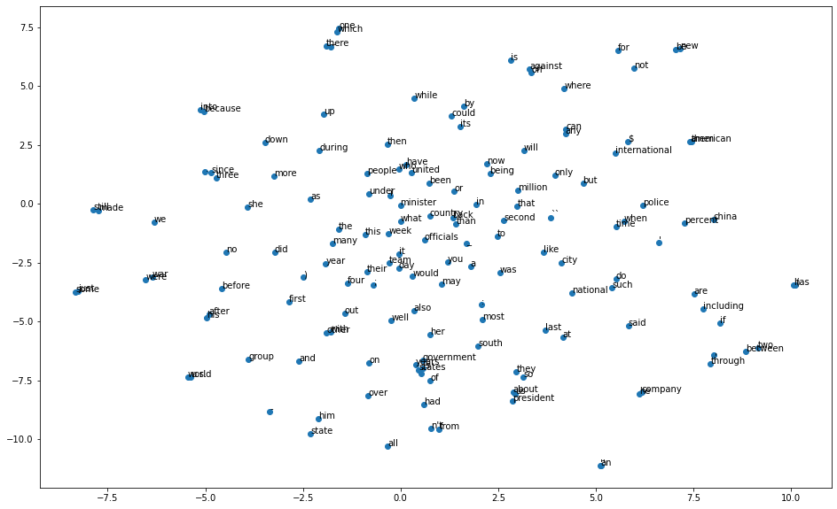

```python
distri = TSNE(n_components=2)
words = list(embeddings_index.keys())
vectors = [embeddings_index[word] for word in words]

y = distri.fit_transform(vectors[700:850])

plt.figure(figsize=(16,10))
plt.scatter(y[:, 0],y[:,1])
for label,x,y in zip(words,y[:, 0],y[:,1]):
    plt.annotate(label,xy=(x,y),xytext=(0,0),textcoords='offset points')
plt.show()
```

Comme avec `Word2Vec`, nous allons créer une matrice pour adapter les vecteurs de `Glove` à notre problématique.

La matrice ci-dessous prend l'embedding `Glove embeddings_index` et le vocabulaire `tokenizer.word_index` comme arguments et renvoie une matrice avec les vecteurs de mots aux bons emplacements.

Les mots introuvables du côté de Glove seront transformés en 0.

```python
matrix_glove = np.zeros((vocab_size, 100))


for word, i in tokenizer.word_index.items():
    embedding_vector = embeddings_index.get(word)
    if embedding_vector is not None: # words not found in glove_dict will be all-zeros
        matrix_glove[i] = embedding_vector
```

```python
print(matrix_glove.shape)
```

```
(11803, 100)
```

### Modèle RNN/LSTM

```python
X_train_vect.shape, y_train.shape
```

```
((11200, 22), (11200,))
```

```python
# Définition de la couche Embedding
embedding_layer_gl = Embedding(vocab_size, W2V_SIZE,
                                                input_length=SEQUENCE_LENGTH,
                                                weights=[matrix_glove],
                                                trainable=False)
```

Définition de couches `Embedding, Dropout, LSTM, , Flatten, Dense` :

```python
# Initalisation du modèle
model_rnn_glove = Sequential([])
```

```python
# Ajout de couches
model_rnn_glove.add(layers.Input(shape=(22,)))
model_rnn_glove.add(embedding_layer_gl)
model_rnn_glove.add(Dropout(0.2))

model_rnn_glove.add(layers.LSTM(64, return_sequences=True))
model_rnn_glove.add(layers.Dropout(0.2))
model_rnn_glove.add(layers.LSTM(64, return_sequences=True))
model_rnn_glove.add(layers.Dropout(0.2))

#model.add(Bidirectional(LSTM(128, dropout=0.2, recurrent_dropout=0.2)))

model_rnn_glove.add(layers.Flatten())
model_rnn_glove.add(layers.Dense(1, activation='sigmoid'))
```

```python
# summarize the model
print(model_rnn_glove.summary())
```

```
Model: "sequential_5"
_________________________________________________________________
 Layer (type)                Output Shape              Param #
=================================================================
 embedding_4 (Embedding)     (None, 22, 100)           1180300

 dropout_7 (Dropout)         (None, 22, 100)           0

 lstm_4 (LSTM)               (None, 22, 64)            42240

 dropout_8 (Dropout)         (None, 22, 64)            0

 lstm_5 (LSTM)               (None, 22, 64)            33024

 dropout_9 (Dropout)         (None, 22, 64)            0

 flatten_5 (Flatten)         (None, 1408)              0

 dense_8 (Dense)             (None, 1)                 1409

=================================================================
Total params: 1,256,973
Trainable params: 76,673
Non-trainable params: 1,180,300
_________________________________________________________________
None
```

```python
# Compilation du modèle
model_rnn_glove.compile(
    optimizer='adam', # L'algorithme d'optimisation pour trouver les poids
    loss='binary_crossentropy', # car classification binaire
    metrics=[
        'accuracy',
        tf.keras.metrics.AUC(name='auc')
    ]
)
```

```python
start_time = time.time()

history_rnn_glove = model_rnn_glove.fit(
    X_train_vect,
    y_train,
    validation_split=0.2,
    batch_size=BATCH_SIZE,
    epochs=EPOCHS,
    callbacks=CALLBACKS
)
end_time = time.time()
time_rnn_glove = end_time - start_time
```

```
Epoch 10: early stopping
```

```python
## 57.2s
time_rnn_glove = round_elapsed_time(time_rnn_glove)
print("Temps d'exécution :", time_rnn_glove, "secondes.")
```

```
Temps d'exécution : 37.26 secondes.
```

### Evaluation du modèle

#### Accuracy, AUC, Loss

```python
results_rnn_gl = model_rnn_glove.evaluate(np.array(X_test_vect), np.array(y_test), verbose=0)

print("    Test Loss: {:.4f}".format(results_rnn_gl[0]))
print("Test Accuracy: {:.2f}%".format(results_rnn_gl[1] * 100))
print("     Test AUC: {:.4f}".format(results_rnn_gl[2]))
```

```
    Test Loss: 0.8915
Test Accuracy: 50.10%
     Test AUC: 0.5024
```

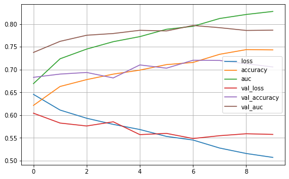

```python
evolution_mesures(history_rnn_glove)
```

#### ROC AUC

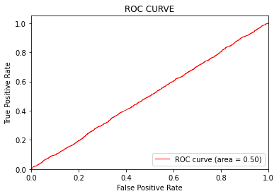

```python
courbe_roc(model_rnn_glove)
```

#### Overfitting / underfitting

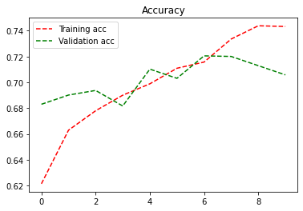

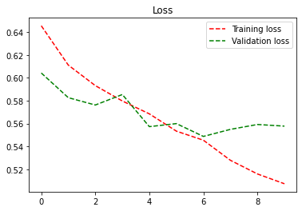

```python
overfitting_underfitting(history_rnn_glove)
```

#### Matrice de confusion

```python
y_pred = []
y_test = list(test.Label)
scores = model_rnn_glove.predict(X_test_vect, verbose=0, batch_size=8000)
y_pred = [decode_sentiment(score) for score in scores]
```

```python
print(classification_report(y_test, y_pred))
```

```
              precision    recall  f1-score   support

           0       0.51      0.52      0.52      2452
           1       0.49      0.48      0.48      2348

    accuracy                           0.50      4800
   macro avg       0.50      0.50      0.50      4800
weighted avg       0.50      0.50      0.50      4800
```

```python
# Stock F1
f1_rnn_glove=round(f1_score(y_test, y_pred),2)
```

```python
conf_matrix = confusion_matrix(y_test, y_pred)
```

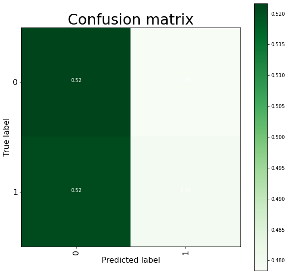

```python
plt.figure(figsize=(10,10))
plot_confusion_matrix(conf_matrix, classes=train.Label.unique(), title="Confusion matrix")
plt.show()
```

### Modèle CNN

```python
X_train_vect.shape, y_train.shape
```

```
((11200, 22), (11200,))
```

```python
# Inistialisation du modèle
model_cnn_glove = Sequential()
```

```python
# Ajout de couches
model_cnn_glove.add(embedding_layer_gl)
model_cnn_glove.add(Conv1D(filters=128, kernel_size=5, activation='relu'))
model_cnn_glove.add(MaxPooling1D(pool_size=2))
model_cnn_glove.add(Dropout(0.25))
model_cnn_glove.add(Flatten())
model_cnn_glove.add(Dense(1, activation='sigmoid'))
```

```python
print(model_cnn_glove.summary())
```

```
Model: "sequential_6"
_________________________________________________________________
 Layer (type)                Output Shape              Param #
=================================================================
 embedding_4 (Embedding)     (None, 22, 100)           1180300

 conv1d_4 (Conv1D)           (None, 18, 128)           64128

 max_pooling1d_2 (MaxPooling  (None, 9, 128)           0
 1D)

 dropout_10 (Dropout)        (None, 9, 128)            0

 flatten_6 (Flatten)         (None, 1152)              0

 dense_9 (Dense)             (None, 1)                 1153

=================================================================
Total params: 1,245,581
Trainable params: 65,281
Non-trainable params: 1,180,300
_________________________________________________________________
None
```

```python
# Compilation du modèle
model_cnn_glove.compile(
    optimizer='adam', #L'algorithme d'optimisation pour trouver les poids
    loss='binary_crossentropy', # car classification binaire
    metrics=[
        'accuracy',
        tf.keras.metrics.AUC(name='auc')
    ]
)
```

```python
start_time = time.time()


history_cnn_glove = model_cnn_glove.fit(
                    X_train_vect,
                    y_train,
                    validation_split=0.2,
                    batch_size=BATCH_SIZE,
                    epochs=EPOCHS,
                    callbacks=CALLBACKS
                )
end_time = time.time()
time_cnn_glove = end_time - start_time
```

```
Epoch 6: early stopping
```

```python
## 57.2s
time_cnn_glove = round_elapsed_time(time_cnn_glove)
print("Temps d'exécution :", time_cnn_glove, "secondes.")
```

```
Temps d'exécution : 7.63 secondes.
```

### Evaluation du modèle

#### Accuracy, AUC, Loss

```python
results_cnn_gl = model_cnn_glove.evaluate(np.array(X_test_vect), np.array(y_test), verbose=0)

print("    Test Loss: {:.4f}".format(results_cnn_gl[0]))
print("Test Accuracy: {:.2f}%".format(results_cnn_gl[1] * 100))
print("     Test AUC: {:.4f}".format(results_cnn_gl[2]))
```

```
    Test Loss: 0.8378
Test Accuracy: 50.54%
     Test AUC: 0.5105
```

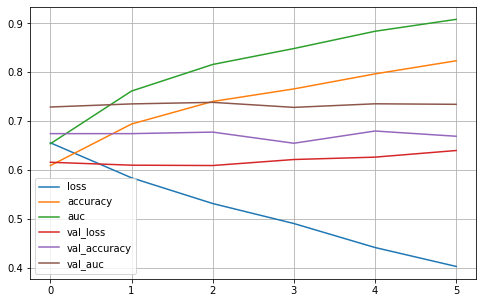

```python
evolution_mesures(history_cnn_glove)
```

#### ROC AUC

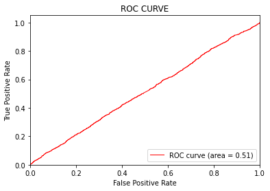

```python
courbe_roc(model_cnn_glove)
```

#### Overfitting / underfitting

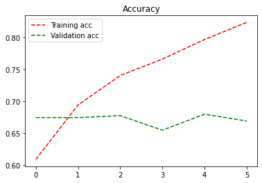

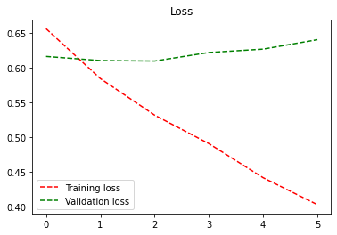

```python
overfitting_underfitting(history_cnn_glove)
```

#### Matrice de confusion

```python
y_pred = []
y_test = list(test.Label)
scores = model_cnn_glove.predict(X_test_vect, verbose=0, batch_size=8000)
y_pred = [decode_sentiment(score) for score in scores]
```

```python
print(classification_report(y_test, y_pred))
```

```
              precision    recall  f1-score   support

           0       0.52      0.42      0.47      2452
           1       0.50      0.59      0.54      2348

    accuracy                           0.51      4800
   macro avg       0.51      0.51      0.50      4800
weighted avg       0.51      0.51      0.50      4800
```

```python
# Stock F1
f1_cnn_glove=round(f1_score(y_test, y_pred),2)
```

```python
conf_matrix = confusion_matrix(y_test, y_pred)
```

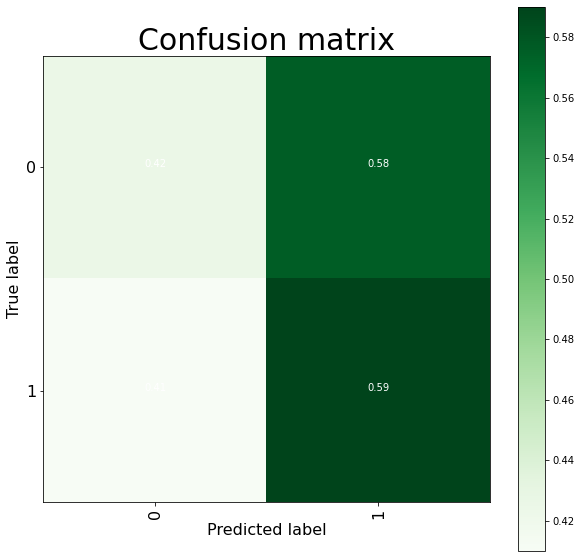

```python
plt.figure(figsize=(10,10))
plot_confusion_matrix(conf_matrix, classes=train.Label.unique(), title="Confusion matrix")
plt.show()
```

# BERT

BERT (`Bidirectional Encoder Representations from Transformers`) est une grande architecture de réseau de neurones, avec un grand nombre de paramètres, pouvant aller de 100 millions à plus de 300 millions.

Il est donc préférable d'utiliser un modèle BERT pré-formé comme point de départ. Nous pouvons ensuite entraîner le modèle sur notre jeu de données relativement plus petit (fine tuning).

### Chargement modèle pré-entraîné

Chargeons le tokenizer BERT et le modèle BERT qui nous convient.

```python
# Transformers
#from transformers import BertTokenizer, TFBertModel, BertConfig, TFBertForSequenceClassification
from transformers import *
bert_tokenizer = BertTokenizer.from_pretrained("bert-base-uncased")
```

[output not shown]

Tous les tweets seront convertis en minuscules et tokenisés par le tokenizer. Il est important de mentionner également que le tokenizer **se charge également de diviser la séquence en tokens disponibles** dans le vocabulaire du tokenizer.

```python
data_lemmatized.head()
```

|  | Label | Text | my_tokens |
| --- | --- | --- | --- |
| 0 | 0 | fingers still broked yesterday wasn't just dream! | finger still broked yesterday dream |
| 1 | 0 | @shaulala dayaa!we weren't allowed twiter e-class | dayaa allow twiter e class |
| 2 | 0 | @Zzachary17 awe. wish could | awe wish could |
| 3 | 0 | @dream0176 sending hugs your way...sorry hear ... | send hug way sorry hear |
| 4 | 0 | @peacenlove |  |

```python
num_classes=len(data_lemmatized.Label.unique())
bert_model = TFBertForSequenceClassification.from_pretrained('bert-base-uncased',num_labels=num_classes)
```

[output not shown]

Visualisation du résultat de tokénisation BERT sur un tweet du corpus :

```python
bert_tokenizer.tokenize(data_lemmatized.Text[1])
```

```
['@',
 'sha',
 '##ula',
 '##la',
 'day',
 '##aa',
 '!',
 'we',
 'weren',
 "'",
 't',
 'allowed',
 't',
 '##wi',
 '##ter',
 'e',
 '-',
 'class']
```

Pour indiquer que les tokens ne sont pas des mots séparés mais des parties du même mot, un préfixe à double hachage est ajouté : `##wi, ##ter`.

#### Préparation du corpus et de la target

```python
sample_bert = data_lemmatized.groupby("Label").sample(n=800, random_state=1)
```

```python
sample_bert.Label.value_counts()
```

```
0    800
1    800
Name: Label, dtype: int64
```

```python
sentences=sample_bert['my_tokens']
labels=sample_bert['Label']
len(sentences),len(labels)
```

```
(1600, 1600)
```

### Techniques d'attention : identifiants, masques

- `input_ids` : Ce sont des indices de tokens, des représentations numériques de tokens construisant les séquences qui seront utilisées en entrée par le modèle.
- `attention_masks` : Masque pour éviter de prêter attention aux tokens en mode padding. Valeurs de masque sélectionnées entre 0 et 1 :
  - 1 pour les tokens non masqués,
  - 0 pour les tokens marsqués (0 aussi si ajout via padding). Cet argument indique au modèle quels tokens doivent être pris en compte et lesquels ne doivent pas l'être.

```python
input_ids = []
attention_masks = []

for sent in sentences:
    bert_inp = bert_tokenizer.encode_plus(
        sent, add_special_tokens=True, max_length=64, pad_to_max_length=True, return_attention_mask=True)
    input_ids.append(bert_inp['input_ids'])
    attention_masks.append(bert_inp['attention_mask'])

input_ids = np.asarray(input_ids)
attention_masks = np.array(attention_masks)
labels = np.array(labels)
```

[output not shown]

Le tokenizer renvoie un dictionnaire avec tous les arguments nécessaires au bon fonctionnement du modèle.

```python
len(input_ids),len(attention_masks),len(labels)
```

```
(1600, 1600, 1600)
```

```python
attention_masks[1]
```

```
array([1, 1, 1, 1, 1, 1, 1, 1, 1, 0, 0, 0, 0, 0, 0, 0, 0, 0, 0, 0, 0, 0,
       0, 0, 0, 0, 0, 0, 0, 0, 0, 0, 0, 0, 0, 0, 0, 0, 0, 0, 0, 0, 0, 0,
       0, 0, 0, 0, 0, 0, 0, 0, 0, 0, 0, 0, 0, 0, 0, 0, 0, 0, 0, 0])
```

```python
input_ids[1]
```

```
array([ 101, 2228, 5576, 2843, 4157, 9467, 4392, 4933,  102,    0,    0,
          0,    0,    0,    0,    0,    0,    0,    0,    0,    0,    0,
          0,    0,    0,    0,    0,    0,    0,    0,    0,    0,    0,
          0,    0,    0,    0,    0,    0,    0,    0,    0,    0,    0,
          0,    0,    0,    0,    0,    0,    0,    0,    0,    0,    0,
          0,    0,    0,    0,    0,    0,    0,    0,    0])
```

```python
bert_tokenizer.decode(bert_inp['input_ids'])
```

```
'[CLS] sorry late reply reply kasi [SEP] [PAD] [PAD] [PAD] [PAD] [PAD] [PAD] [PAD] [PAD] [PAD] [PAD] [PAD] [PAD] [PAD] [PAD] [PAD] [PAD] [PAD] [PAD] [PAD] [PAD] [PAD] [PAD] [PAD] [PAD] [PAD] [PAD] [PAD] [PAD] [PAD] [PAD] [PAD] [PAD] [PAD] [PAD] [PAD] [PAD] [PAD] [PAD] [PAD] [PAD] [PAD] [PAD] [PAD] […
```

Des tokens spéciaux `classificateur [CLS], séparateur [SEP]) et padding [PAD]` sont ajoutés par le tokenizer.

```python
print('Preparing the pickle file.....')

pickle_inp_path='/home/sylwia/Jupyter/P7_BadBuzz/bert/bert_inp.pkl'
pickle_mask_path='/home/sylwia/Jupyter/P7_BadBuzz/bert/bert_mask.pkl'
pickle_label_path='/home/sylwia/Jupyter/P7_BadBuzz/bert/bert_label.pkl'

pickle.dump((input_ids),open(pickle_inp_path,'wb'))
pickle.dump((attention_masks),open(pickle_mask_path,'wb'))
pickle.dump((labels),open(pickle_label_path,'wb'))

print('Pickle files saved as ',pickle_inp_path,pickle_mask_path,pickle_label_path)
```

```
Preparing the pickle file.....
Pickle files saved as  /home/sylwia/Jupyter/P7_BadBuzz/bert/bert_inp.pkl /home/sylwia/Jupyter/P7_BadBuzz/bert/bert_mask.pkl /home/sylwia/Jupyter/P7_BadBuzz/bert/bert_label.pkl
```

```python
print('Loading the saved pickle files..')

input_ids=pickle.load(open(pickle_inp_path, 'rb'))
attention_masks=pickle.load(open(pickle_mask_path, 'rb'))
labels=pickle.load(open(pickle_label_path, 'rb'))

print('Input shape {} Attention mask shape {} Input label shape {}'.format(input_ids.shape,attention_masks.shape,labels.shape))
```

```
Loading the saved pickle files..
Input shape (1600, 64) Attention mask shape (1600, 64) Input label shape (1600,)
```

### Séparation train / val / mask

```python
train_inp, val_inp, train_label, val_label, train_mask, val_mask = train_test_split(
    input_ids, labels, attention_masks, test_size=0.2)


print('Train inp shape {} Val input shape {}\nTrain label shape {} Val label shape {}\nTrain attention mask shape {} Val attention mask shape {}'.format(
    train_inp.shape, val_inp.shape, train_label.shape, val_label.shape, train_mask.shape, val_mask.shape))
```

```
Train inp shape (1280, 64) Val input shape (320, 64)
Train label shape (1280,) Val label shape (320,)
Train attention mask shape (1280, 64) Val attention mask shape (320, 64)
```

### Création du modèle

```python
log_dir = 'tensorboard_data/tb_bert'
model_save_path = '/home/sylwia/Jupyter/P7_BadBuzz/tf/bert_model.h5'

callbacks = [tf.keras.callbacks.ModelCheckpoint(
    filepath=model_save_path,
    save_weights_only=True,
    monitor='val_loss',
    mode='min',
    save_best_only=True),
    keras.callbacks.TensorBoard(log_dir=log_dir)]
```

```python
print('\nBert Model',bert_model.summary())
```

```
Model: "tf_bert_for_sequence_classification"
_________________________________________________________________
 Layer (type)                Output Shape              Param #
=================================================================
 bert (TFBertMainLayer)      multiple                  109482240

 dropout_48 (Dropout)        multiple                  0

 classifier (Dense)          multiple                  1538

=================================================================
Total params: 109,483,778
Trainable params: 109,483,778
Non-trainable params: 0
_________________________________________________________________

Bert Model None
```

```python
loss = tf.keras.losses.SparseCategoricalCrossentropy(from_logits=True)
metric = tf.keras.metrics.SparseCategoricalAccuracy('accuracy')
optimizer = tf.keras.optimizers.Adam(learning_rate=2e-5,epsilon=1e-08)

bert_model.compile(loss=loss,optimizer=optimizer,metrics=[metric])
```

#### Entraînement du modèle

```python
start_time = time.time()

history_bert = bert_model.fit([train_inp, train_mask],
                         train_label,
                         batch_size=16,
                         epochs=4,
                         validation_data=([val_inp, val_mask], val_label),
                         callbacks=callbacks)
end_time = time.time()
time_bert = end_time - start_time
```

```python
time_bert = round_elapsed_time(time_bert)
print("Temps d'exécution :", time_bert, "secondes.")
```

```
Temps d'exécution : 1940.3 secondes.
```

### Evaluation du modèle

```python
preds = bert_model.predict([val_inp,val_mask],batch_size=8000)
pred_labels = np.argmax(preds.logits, axis=1)
```

#### Accuracy, AUC, Loss

```python
results_bert = bert_model.evaluate(np.array(val_label), np.array(pred_labels), verbose=0)

print("Test Loss: {:.4f}".format(results_bert[0]))
print("Test Accuracy: {:.2f}%".format(results_bert[1] * 100))
#print("     Test AUC: {:.4f}".format(results_bert[2]))
```

```
Test Loss: 0.6685
Test Accuracy: 60.31%
```

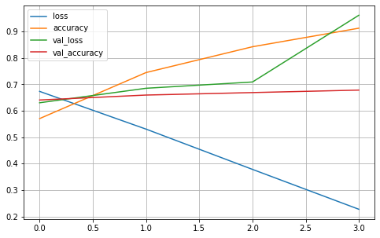

```python
evolution_mesures(history_bert)
```

#### ROC AUC

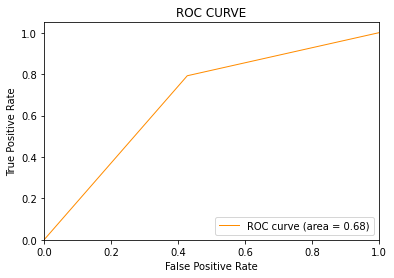

```python
fpr, tpr, thresholds = roc_curve(val_label, pred_labels)
roc_auc = auc(fpr, tpr)
plt.figure()
plt.plot(fpr, tpr, color='darkorange', lw=1, label='ROC curve (area = %0.2f)' % roc_auc)
plt.xlim([0.0, 1.0])
plt.ylim([0.0, 1.05])
plt.xlabel('False Positive Rate')
plt.ylabel('True Positive Rate')
plt.title('ROC CURVE')
plt.legend(loc="lower right")
plt.show()
```

#### Overfitting / underfitting

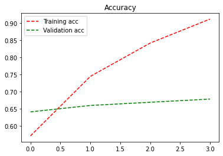

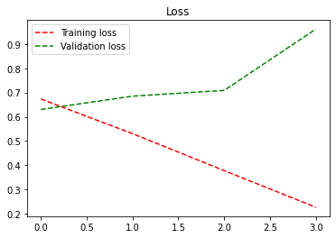

```python
overfitting_underfitting(history_bert)
```

#### Matrice de confusion

```python
print(classification_report(val_label, pred_labels))
```

```
              precision    recall  f1-score   support

           0       0.75      0.57      0.65       166
           1       0.63      0.79      0.70       154

    accuracy                           0.68       320
   macro avg       0.69      0.68      0.68       320
weighted avg       0.69      0.68      0.67       320
```

```python
# Stock F1
f1_bert=round(f1_score(val_label, pred_labels),2)
```

```python
conf_matrix = confusion_matrix(val_label, pred_labels)
```

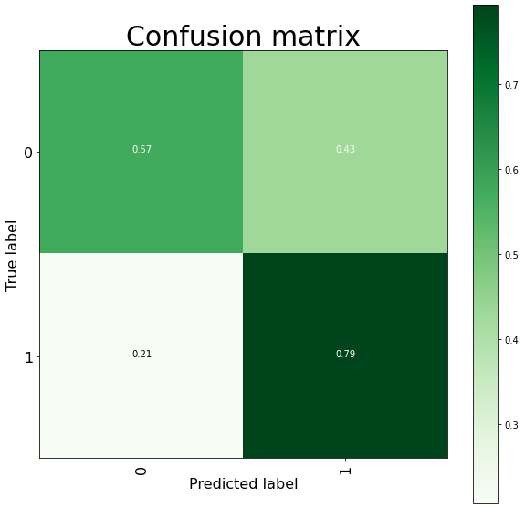

```python
plt.figure(figsize=(10,10))
plot_confusion_matrix(conf_matrix, classes=train.Label.unique(), title="Confusion matrix")
plt.show()
```

## Fichier récapitulatif

Voici le récapitulatif des performances de tous les modèles entraînés dans ce notebook.

```python
log_reg = ["/",0.72,0.72,1.19,0.72]
hypermodel = [round(results_hypermodel[0],2),round(results_hypermodel[1],2),round(results_hypermodel[2],2),time_hypermodel,f1_hypermodel]
rnn_w2v = [round(results_rnn_w2v[0],2),round(results_rnn_w2v[1],2),round(results_rnn_w2v[2],2),time_rnn_w2v,f1_rnn_w2v]
cnn_w2v = [round(results_cnn_w2v[0],2),round(results_cnn_w2v[1],2),round(results_cnn_w2v[2],2),time_cnn_w2v,f1_cnn_w2v]
rnn_gl = [round(results_rnn_gl[0],2),round(results_rnn_gl[1],2),round(results_rnn_gl[2],2),time_rnn_glove,f1_rnn_glove]
cnn_gl = [round(results_cnn_gl[0],2),round(results_cnn_gl[1],2),round(results_cnn_gl[2],2),time_cnn_glove,f1_cnn_glove]
bert_lemma = [round(results_bert[0],2),round(results_bert[1],2),round(roc_auc,2),time_bert,f1_bert]


all_scores = {
    'Logistic Regression':(log_reg),
    'Keras Emb LEMMA':(hypermodel),
    'W2V RNN / LSTM LEMMA':(rnn_w2v),
    'W2V CNN LEMMA':(cnn_w2v),
    'Glove RNN / LSTM LEMMA':(rnn_gl),
    'Glove CNN LEMMA':(cnn_gl),
    'BERT LEMMA':(bert_lemma)
}


test_df = pd.DataFrame(all_scores)
test_df.index= ['Loss','Acc','AUROC','Time','F1']
test_df.T
```

|  | Loss | Acc | AUROC | Time | F1 |
| --- | --- | --- | --- | --- | --- |
| Logistic Regression | / | 0.72 | 0.72 | 1.19 | 0.72 |
| Keras Emb LEMMA | 0.6 | 0.69 | 0.76 | 5.18 | 0.53 |
| W2V RNN / LSTM LEMMA | 0.81 | 0.51 | 0.51 | 49.0 | 0.51 |
| W2V CNN LEMMA | 0.81 | 0.5 | 0.5 | 11.88 | 0.54 |
| Glove RNN / LSTM LEMMA | 0.89 | 0.5 | 0.5 | 37.26 | 0.48 |
| Glove CNN LEMMA | 0.84 | 0.51 | 0.51 | 7.63 | 0.54 |
| BERT LEMMA | 0.67 | 0.6 | 0.68 | 1940.3 | 0.7 |

### Sources

- https://openclassrooms.com/fr/courses/4470541-analysez-vos-donnees-textuelles/4855006-effectuez-des-plongements-de-mots-word-embeddings
- https://analyticsindiamag.com/hands-on-guide-to-word-embeddings-using-glove/
- https://machinelearningmastery.com/develop-word-embedding-model-predicting-movie-review-sentiment/
- https://nanonets.com/blog/hyperparameter-optimization/
- https://penseeartificielle.fr/comprendre-lstm-gru-fonctionnement-schema/#Comment_fonctionne_un_RNN
- https://coderzcolumn.com/tutorials/artificial-intelligence/keras-cnn-with-conv1d-for-text-classification
- https://medium.com/smileinnovation/lstm-intelligence-artificielle-9d302c723eda
- https://lesdieuxducode.com/blog/2019/4/bert--le-transformer-model-qui-sentraine-et-qui-represente
- https://swatimeena989.medium.com/bert-text-classification-using-keras-903671e0207d
- https://www.analyticsvidhya.com/blog/2021/05/tuning-the-hyperparameters-and-layers-of-neural-network-deep-learning/
- https://www.tensorflow.org/tutorials/keras/keras_tuner

```python
# POUR LA PRESA : https://coderzcolumn.com/tutorials/artificial-intelligence/keras-cnn-with-conv1d-for-text-classification
#https://lesdieuxducode.com/blog/2019/4/bert--le-transformer-model-qui-sentraine-et-qui-represente
```